# Evolution of international research collaborative efforts to develop non-Cochrane systematic reviews

# FIGURE 3

This panel represent frequency and time-course changes of SR protocol publication by journals.

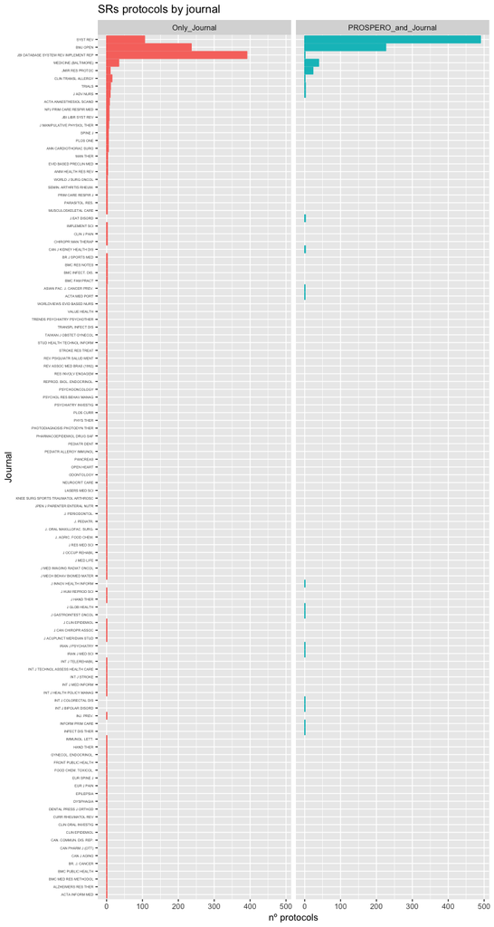

```r
new_data_journal<-subset(new_data, group=="Only_Journal" | group=="PROSPERO_and_Journal")
table_journal <- as.data.frame(table(new_data_journal[,c(11)]))
new_data_journal_2<-merge(new_data_journal, table_journal, by.x="publication_journal", by.y = "Var1", all.x = TRUE)

ggplot(new_data_journal_2,aes(x=(reorder(publication_journal, Freq)), group=group, fill=group, color=group)) +
facet_grid(~group)+
geom_bar () +
coord_flip()+
theme(axis.text.y=element_text(size=4))+
xlab("Journal") +
ylab("nº protocols")+
ggtitle("SRs protocols by journal")+
  theme(legend.position="none")
```

1. Frequency of protocols published from 2011 to 2017 by journal comparing those protocols published ‘only in a journal’ with those protocols published in both ‘journal and PROSPERO’.

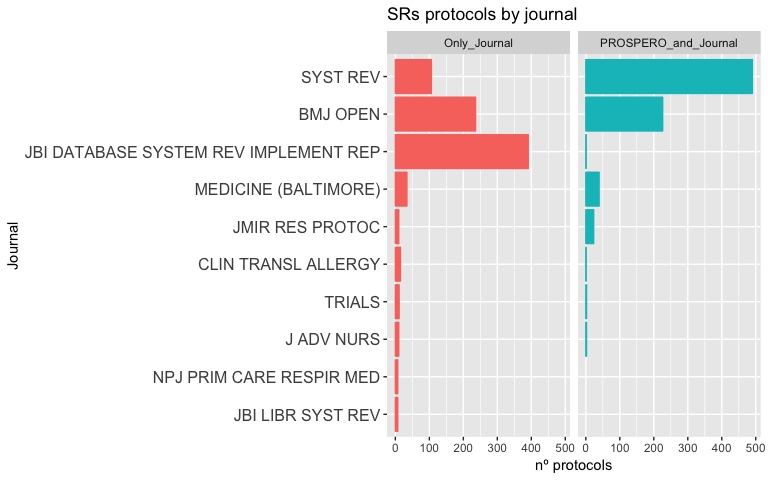

```r
new_data_journal_top<-subset(new_data_journal,  publication_journal=="SYST REV"
                               | publication_journal=="BMJ OPEN"
                               | publication_journal=="JBI DATABASE SYSTEM REV IMPLEMENT REP"
                               | publication_journal=="JMIR RES PROTOC"
                               | publication_journal=="MEDICINE (BALTIMORE)"
                               | publication_journal=="CLIN TRANSL ALLERGY"
                               | publication_journal=="TRIALS"
                               | publication_journal=="J ADV NURS"
                               | publication_journal=="JBI LIBR SYST REV"
                               | publication_journal=="NPJ PRIM CARE RESPIR MED" )

table_journal_2 <- as.data.frame(table(new_data_journal_top[,c(11)]))
new_data_journal_3<-merge(new_data_journal_top, table_journal_2, by.x="publication_journal", by.y = "Var1", all.x = TRUE)

ggplot(new_data_journal_3,aes(x=(reorder(publication_journal, Freq)), group=group, fill=group, color=group)) +
facet_grid(~group)+
geom_bar () +
coord_flip()+
theme(axis.text.y=element_text(size=12))+
xlab("Journal") +
ylab("nº protocols")+
ggtitle("SRs protocols by journal")+
  theme(legend.position="none")
```

2. Magnified vision of plot (a) centered on TOP10 most publisher journals.

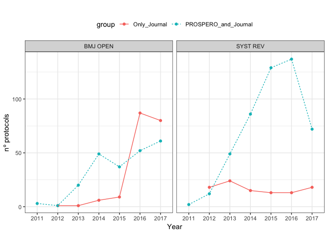

```r
new_data_journal_top_2<-subset(new_data_journal,  publication_journal=="SYST REV"
                               | publication_journal=="BMJ OPEN")

new_data_journal_top_2<-subset(new_data_journal_top_2,  ALL_year!="2018")

ggplot(new_data_journal_top_2,aes(x=ALL_year, group=group, fill=group, color=group,linetype=group)) +
facet_grid(~publication_journal)+
geom_point(stat = "count") +
geom_line(stat = 'count', aes(group = group, colour = group, linetype=group))+
#coord_flip()+
theme(axis.text.y=element_text(size=4))+
xlab("Year") +
ylab("nº protocols")+
ggtitle(" ")+
  theme_bw()+
  theme(legend.position="top")
```

3. Evolution of ‘only journal’ vs ‘journal and PROSPERO’ protocols publications from 2011 to 2017 comparing ‘BMJ open’ and ‘Systematic Reviews’ journals.

# Figure 4.

This panel represent frequency and time-course changes of SR protocol publication by countries.

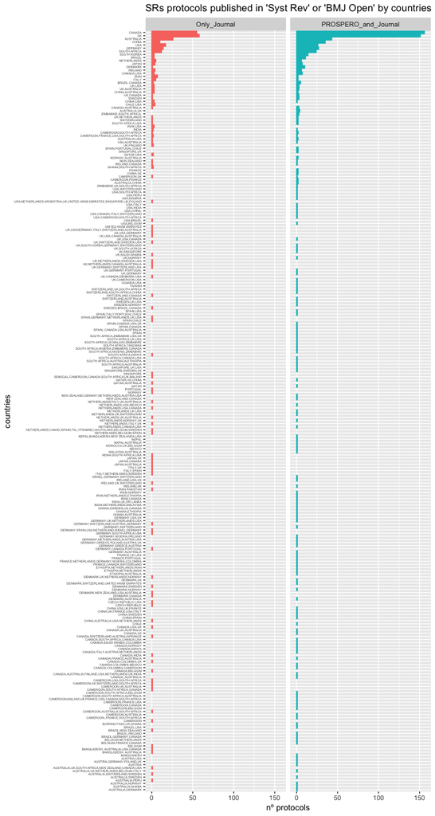

```r
new_data_journal_top_2<-subset(new_data_journal,  publication_journal=="SYST REV"
                               | publication_journal=="BMJ OPEN")

table_all_countries <- as.data.frame(table(new_data_journal_top_2[,c(16)]))
all_countries<-merge(new_data_journal_top_2, table_all_countries, by.x="ALL_country_curated", by.y = "Var1", all.x = TRUE)

ggplot(na.omit(all_countries[,c(1,3,41)]),aes(x=(reorder(ALL_country_curated, Freq)), group=group, fill=group, color=group)) +
facet_grid(~group)+
geom_bar()+
coord_flip()+
theme(axis.text.y=element_text(size=4))+
xlab("countries") +
ylab("nº protocols")+
theme(legend.position=" ")+
ggtitle("SRs protocols published in 'Syst Rev' or 'BMJ Open' by countries")
```

1. Frequency of protocols published from 2011 to 2017 by country comparing those protocols published ‘only in a journal’ with those protocols published in both ‘journal and PROSPERO’.

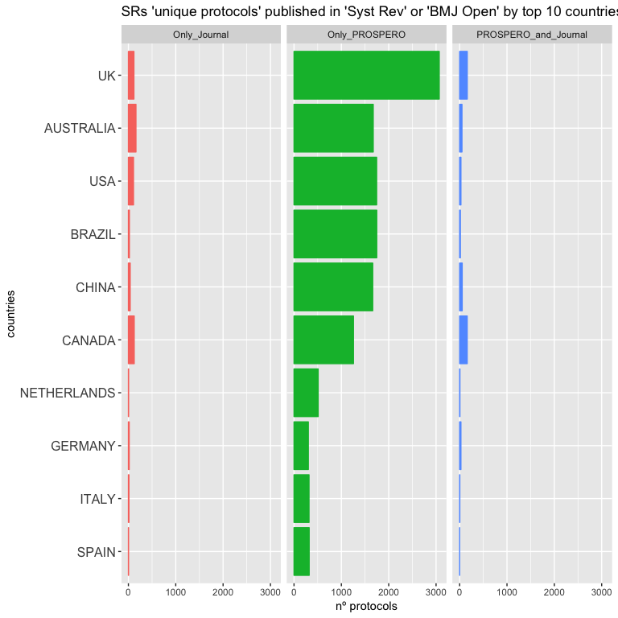

```r
unique_countries<-new_data %>%
  filter(!str_detect(ALL_country_curated, ','))
unique_countries_all<-unique_countries %>%
  filter(!str_detect(ALL_country_curated, '\t'))

table_all_unique_countries <- as.data.frame(table(unique_countries_all[,c(16)]))
table_country              <- subset(table_all_unique_countries, Freq>1)
unique_countries_dataset   <- merge(unique_countries_all, table_all_unique_countries, by.x="ALL_country_curated", by.y = "Var1", all.x = TRUE)
unique_countries_dataset   <- unique_countries_dataset[,c(1,3,41)]

ordered_unique_countries_dataset <- arrange(unique_countries_dataset, desc(ALL_country_curated, Freq))
select<-c("UK", "AUSTRALIA", "USA", "BRAZIL", "CHINA", "CANADA","NETHERLANDS","GERMANY","ITALY","SPAIN")
ordered_unique_countries_dataset<-ordered_unique_countries_dataset[ordered_unique_countries_dataset$ALL_country_curated %in% select, ]

ggplot(na.omit(ordered_unique_countries_dataset),aes(x=reorder(ALL_country_curated, Freq), group=group, fill=group, color=group)) +
facet_grid(~group)+
geom_bar()+
coord_flip()+
theme(axis.text.y=element_text(size=12))+
xlab("countries") +
ylab("nº protocols")+
  theme(legend.position="none")+
ggtitle("SRs 'unique protocols' published in 'Syst Rev' or 'BMJ Open' by top 10 countries")
```

2. Magnified vision of plot (a) centered on top 10 most productive countries comparing those protocols published ‘only in a journal’, ‘’only at PROSPERO’, and in both ‘journal and PROSPERO’.

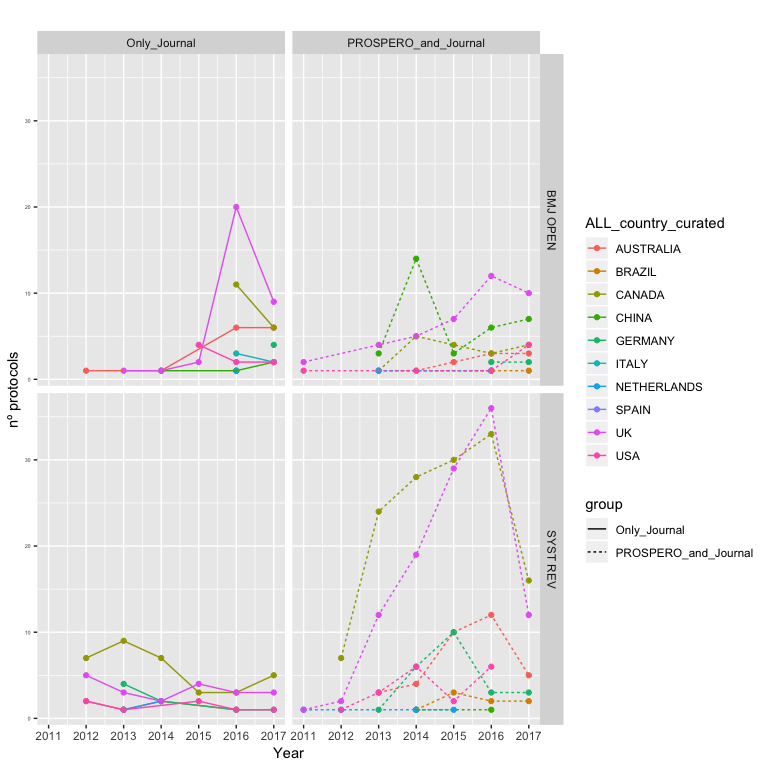

```r
unique_countries<-new_data %>%
  filter(!str_detect(ALL_country_curated, ','))
unique_countries_all<-unique_countries %>%
  filter(!str_detect(ALL_country_curated, '\t'))

table_all_unique_countries <- as.data.frame(table(unique_countries_all[,c(16)]))
table_country              <- subset(table_all_unique_countries, Freq>1)
unique_countries_dataset   <- merge(unique_countries_all, table_all_unique_countries, by.x="ALL_country_curated", by.y = "Var1", all.x = TRUE)
unique_countries_dataset   <- unique_countries_dataset[,c(1,3,8,12,41)]

ordered_unique_countries_dataset <- arrange(unique_countries_dataset, desc(ALL_country_curated, Freq))
select<-c("UK", "AUSTRALIA", "USA", "BRAZIL", "CHINA", "CANADA","NETHERLANDS","GERMANY","ITALY","SPAIN")
ordered_unique_countries_dataset<-ordered_unique_countries_dataset[ordered_unique_countries_dataset$ALL_country_curated %in% select, ]
ordered_unique_countries_dataset<-subset(ordered_unique_countries_dataset,  publication_journal=="SYST REV"
                                         | publication_journal=="BMJ OPEN")

ordered_unique_countries_dataset$ALL_year<-as.numeric(as.character(ordered_unique_countries_dataset$ALL_year))

ggplot(na.omit(ordered_unique_countries_dataset),aes(x=ALL_year,color=ALL_country_curated,linetype=group)) +
  geom_point(stat = 'count') +
  geom_line(stat='count',aes(x=ALL_year,color=ALL_country_curated,linetype=group))+
  theme(axis.text.y=element_text(size=4))+
  facet_grid(publication_journal~group)+
  scale_x_continuous(limits=c(2011, 2017), breaks = c(2011,2012,2013,2014,2015,2016,2017))+
  xlab("Year") +
  ylab("nº protocols")+
  ggtitle(" ")
```

3. Evolution of ‘only journal’ vs ‘journal and PROSPERO’ ‘unique protocols’ published from 2011 to 2017 comparing top 10 countries.

# Figure 5.

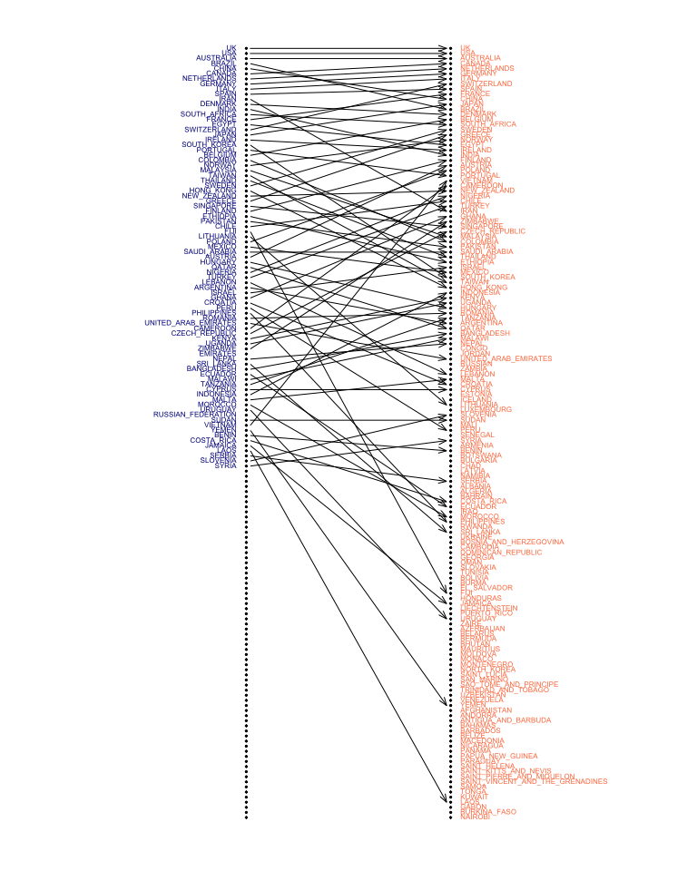

```r
all_rank    <- read.csv(file="both_rank_lists_countries.csv", sep=";")
unique      <- rev(as.vector(all_rank$country_unique))
colaborate  <- rev(as.vector(all_rank$country_col))
plotRanks(unique,colaborate)
```

Rank discrepancies between two ordered lists of reviewers’ affiliation countries. The ‘Unique protocols’ column displays a descendent list of reviewers’ affiliation countries that produced protocols for which all reviewers’ institutions belonged to an unique country. The ‘Collaborative protocols’ column displays a ranked list of reviewers’ affiliation countries that collaborated with other reviewers’ affiliation countries to produce protocols for SRs. Arrows connect the same country from first to second list. Countries represented only in one of the lists are not connected to/by any arrow.

The final plot appearing in the manuscript was edited using Keynote to get countries sub-grouped (Q1:Q4) by cutting through 25%, 50%, and 75% of total number of countries in each list. When comparing ‘Unique protocols’ and ‘Collaborative protocols’ lists, country position is considered being modified if the edge connects two different subgroups (i.e., Q1). Direction of the change defines ‘upgrading’ (Q2Q1,Q3Q1,Q4Q1, Q3Q2,Q4Q3) or ‘downgrading’ the rank positionofanycountry (Q1Q2,Q1Q3,Q1Q4,Q2Q3,Q2Q4,Q3Q4).

# Figure 6.

Analysis of protocol publication patterns by most productive countries.

```
## geom_path: Each group consists of only one observation. Do you need to
## adjust the group aesthetic?
```

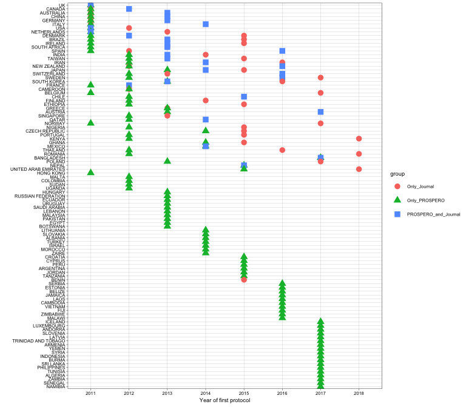

```r
db_3<-read.csv(file="db_2.csv", sep=";")
db_3$FINAL_ORDEN<-as.factor(db_3$FINAL_ORDEN)

a <- db_3$continente_color

ggplot(na.omit(db_3[,c("min_year", "ALL_country_curated", "group", "FINAL_ORDEN", "continente_color")]), aes(x=min_year, y=forcats::fct_reorder(ALL_country_curated,desc(FINAL_ORDEN)), color=group, shape=group, group=interaction(ALL_country_curated, group)))+
  geom_point(aes(colour=group, group=interaction(y=forcats::fct_reorder(ALL_country_curated,desc(FINAL_ORDEN)), group)), size=3)+
  #geom_jitter()+
  geom_line(aes(group=interaction(y=forcats::fct_reorder(ALL_country_curated,desc(FINAL_ORDEN)), group)),color="grey")+
  scale_x_discrete(limits=c(2011,2012,2013,2014,2015,2016,2017,2018))+
  theme(axis.text.y=element_text(colour="continente_color"))+
  theme_linedraw(base_size = 7)+
  xlab("Year of first protocol")+
  ylab(" ")
```

Countries are listed in a descendent order based on their ‘Unique protocol’ productivity. Points represent a hallmark in every country’s history of protocol publication: first time to publish a protocol in ‘only a journal’ (red dot), ‘only at PROSPERO’ (green triangle), and in both ‘journal and PROSPERO’ (blue square).

The final plot appearing in the manuscript was edited using Keynote to get arrows connecting two (by a dotted line) or more (by a full line) hallmarks to emphasize how much time is taken for a country to adopt a new way of publication.